# SLAPNAP Report: VRC01

28 September, 2021

# 1 Executive summary

The broadly neutralizing antibody (bnAb) studied in this analysis is VRC01. The analysis considered 1 measure of neutralization sensitivity: IC$_{80}$. Based on this specification of bnAb and outcome:

- 828 sequences were extracted from the CATNAP database (Yoon et al. 2015);
- 827 sequences had complete geographic and genetic sequence information;
- 572 of these sequences had measured IC$_{80}$.

Prediction of each outcome was performed using a super learner ensemble (van der Laan, Polley, and Hubbard 2007) of several random forests (Breiman 2001) with varied tuning parameters, several gradient boosted trees (Chen and Guestrin 2016) with varied tuning parameters, and several elastic net regressions (Zou and Hastie 2005) with varied tuning parameters and intercept-only regression. Each algorithm (excepting xgboost)was additionally implemented in combination with variable pre-screening procedures to ensure that all binary features had at least 0, 4 minority variants. This constituted a total of 6500/6513, 3841/6513 features, respectively.

The specific algorithms used in the learning process are described in Table 1.1.

Table 1.1: Algorithms used in the super learner library. Each algorithm (excepting xgboost)was additionally implemented in combination with variable pre-screening procedures to ensure that all binary features had at least 0, 4 minority variants.

| Label | Description |
| --- | --- |
| rf_tune1 | random forest with `mtry` equal to one-half times square root of number of predictors |
| rf_default | random forest with `mtry` equal to square root of number of predictors |
| rf_tune2 | random forest with `mtry` equal to two times square root of number of predictors |
| xgboost_default | boosted regression trees with maximum depth of 4 |
| xgboost_tune3 | boosted regression trees with maximum depth of 8 |
| xgboost_tune4 | boosted regression trees with maximum depth of 12 |
| lasso_default | elastic net with $\lambda$ selected by 5-fold CV and $\alpha$ equal to 1 (i.e., the lasso) |
| lasso_tune1 | elastic net with $\lambda$ selected by 5-fold CV and $\alpha$ equal to 0.25 |
| lasso_tune2 | elastic net with $\lambda$ selected by 5-fold CV and $\alpha$ equal to 0.5 |
| lasso_tune3 | elastic net with $\lambda$ selected by 5-fold CV and $\alpha$ equal to 0.75 |
| mean | intercept only regression |

The predictive ability of the learner was assessed using cross-validation. The estimated cross-validated $R^2$ of the learner for predicting IC$_{80}$ is shown in Table 1.2.

Table 1.2: Estimates of 5-fold cross-validated $R^2$ for predictions of IC$_{80}$ (n = 572).

|  | CV-R$^2$ | Lower 95% CI | Upper 95% CI |
| --- | --- | --- | --- |
| IC$_{80}$ | 0.345 | 0.266 | 0.416 |

# 2 Results for IC$_{80}$

## 2.1 Descriptive statistics

A summary of the distribution of IC$_{80}$ for the selected bnAb is shown in Figure 2.1.

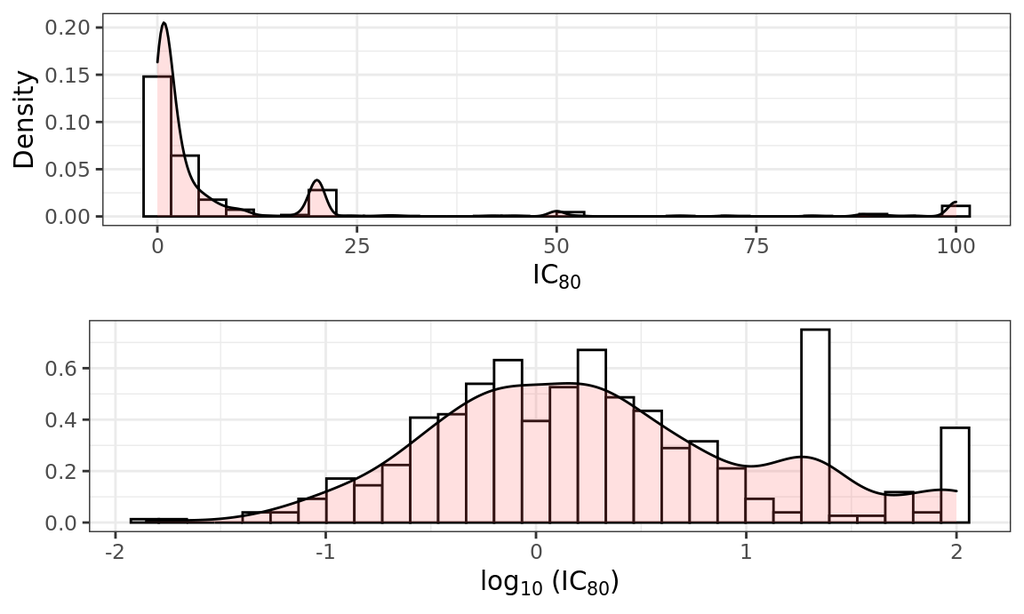

Figure 2.1: Histogram of IC$_{80}$ for the selected bnAb. Top row = original scale; bottom row = log$_{10}$ scale (n = 572 observations).

## 2.2 Super learner results

The weights assigned to each algorithm for Super Learner predicting IC$_{80}$ are shown in Table 2.1.

Table 2.1: Table of super learner weights for IC$_{80}$ (n = 572 observations).

| Learner | Weight |
| --- | --- |
| rf_tune1_screen0 | 0.00 |
| rf_default_screen0 | 0.00 |
| rf_tune2_screen0 | 0.00 |
| lasso_default_screen0 | 0.00 |
| lasso_tune1_screen0 | 0.32 |
| lasso_tune2_screen0 | 0.00 |
| lasso_tune3_screen0 | 0.00 |
| rf_tune1_screen4 | 0.00 |
| rf_default_screen4 | 0.00 |
| rf_tune2_screen4 | 0.00 |
| lasso_default_screen4 | 0.00 |
| lasso_tune1_screen4 | 0.00 |
| lasso_tune2_screen4 | 0.00 |
| lasso_tune3_screen4 | 0.08 |
| xgboost_default | 0.03 |
| xgboost_tune3 | 0.15 |
| xgboost_tune4 | 0.42 |
| mean | 0.00 |

## 2.3 Predictive performance

The cross-validated $R^2$ of the super learner and constituent algorithms (descriptions of algorithms shown in Table 1.1 in predicting IC$_{80}$ are shown in Figure 2.2.

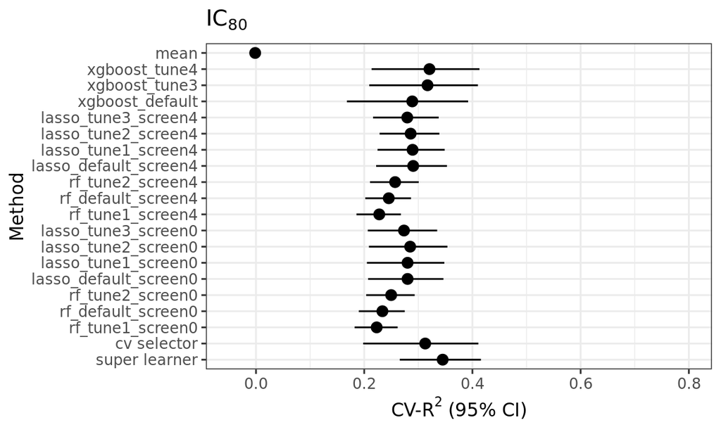

Figure 2.2: Cross-validated $R^2$ for IC$_{80}$ (n = 572 observations)

Figure 2.3 shows cross-validated predictions of IC$_{80}$ plotted against observed values of IC$_{80}$, colored by cross-validation fold.

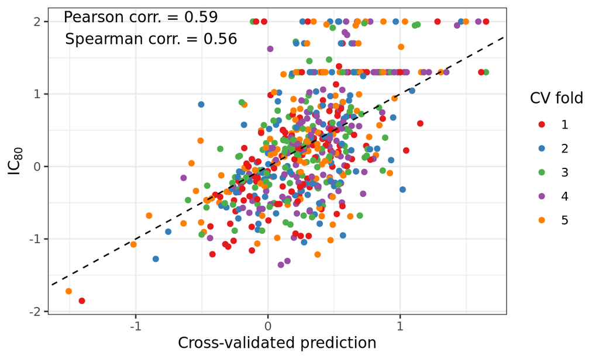

Figure 2.3: Cross-validated super learner predicted log$_{10}$(IC$_{80})$ plotted against observed value (n = 572 observations) . Colors correspond to cross-validation folds.

# References

Breiman, Leo. 2001. “Random Forests.” *Machine Learning* 45 (1). Springer: 5–32. doi:10.1023/A:1010933404324.

Chen, Tianqi, and Carlos Guestrin. 2016. “Xgboost: A Scalable Tree Boosting System.” In *Proceedings of the 22nd Acm Sigkdd International Conference on Knowledge Discovery and Data Mining*, 785–94. doi:10.1145/2939672.2939785.

van der Laan, Mark J, Eric C Polley, and Alan E Hubbard. 2007. “Super Learner.” *Statistical Applications in Genetics and Molecular Biology* 6 (1). De Gruyter. doi:10.2202/1544-6115.1309.

Yoon, Hyejin, Jennifer Macke, Anthony P West Jr, Brian Foley, Pamela J Bjorkman, Bette Korber, and Karina Yusim. 2015. “CATNAP: A Tool to Compile, Analyze and Tally Neutralizing Antibody Panels.” *Nucleic Acids Research* 43 (W1). Oxford University Press: W213–W219. doi:10.1093/nar/gkv404.

Zou, Hui, and Trevor Hastie. 2005. “Regularization and Variable Selection via the Elastic Net.” *Journal of the Royal Statistical Society: Series B (Statistical Methodology)* 67 (2). Wiley Online Library: 301–20. doi:10.1111/j.1467-9868.2005.00503.x.